# Gold Standard - Normalization Assessment

# Datasets

General characteristics of each dataset are depicted in the following table:

| Number | ID | Acquisition | MS instrument | MS instrument (summary) | Analysis Software | Specie | Tissue (specific) | Cell culture | Tissue (summary) | N groups | Group names | Control | Case | Sample size | Publication (DOI) | More docs | Comments | SpecieGrouped | Software |
| --- | --- | --- | --- | --- | --- | --- | --- | --- | --- | --- | --- | --- | --- | --- | --- | --- | --- | --- | --- |
| 1 | PXD016670 | DDA | LTQ Orbitrap | Orbitrap-based | MaxQuant | Saccharomyces cerevisiae | Colonies | Yes | Colonies | 3 | Ctl;psr1psr2;whi2 | Ctl | whi2 | 9 | DOI:10.1073/pnas.1922076117 |  |  | Others | MaxQuant |
| 2 | PXD038236 | DDA | LTQ Orbitrap Elite | Orbitrap-based | FragPipe | Mus musculus | Superior mesenteric artery | No | Heart | 2 | wt;ko | wt | ko | 9 | DOI: 10.1172/jci.insight.164751 |  |  | Mus musculus | Others |
| 3 | PXD054553 | DDA | LTQ Orbitrap Elite | Orbitrap-based | MaxQuant | Homo sapiens | Blood | Yes | Blood | 2 | BJAB;MEC1 | MEC1 | BJAB | 6 | DOI: 10.1016/J.JBC.2025.108386 |  |  | Homo sapiens | MaxQuant |
| 4 | PXD005847 | DDA | LTQ Orbitrap Velos | Orbitrap-based | MaxQuant | Homo sapiens | Serum | No | Blood | 3 | Nash;Norm;SS | Norm | Nash | 15 | DOI: 10.1186/s12014-018-9186-0 | TXT: PXD005847_experimentalDesignTemplate.txt |  | Homo sapiens | MaxQuant |
| 5 | PXD012431 | DDA | LTQ Orbitrap XL ETD | Orbitrap-based | MaxQuant | Homo sapiens | Breast tissues | No | Breast | 4 | axillary metastatic lymph nodes tissues;primary breast tumor tissues;adjacent breast tissues;non-tumor contralateral breast tissues | non-tumor contralateral breast tissues | primary breast tumor tissues | 23 | DOI: 10.1016/j.dib.2019.104125 | TSV: sdrf.tsv with sample annotations |  | Homo sapiens | MaxQuant |
| 6 | PXD022614 | DDA | LTQ Orbitrap;Q Exactive | Orbitrap-based | MaxQuant | Homo sapiens | Brain | No | Brain | 3 | Adult;AdultSperm;Young | Young | AdultSperm | 9 | Pending |  |  | Homo sapiens | MaxQuant |
| 7 | PXD066495 | DDA | Orbitrap Ascend | Orbitrap-based | MaxQuant | Homo sapiens | Monocyte | Yes | Inmune | 4 | Scr_d4;sgALAS1_d4;Scr_d6;sgALAS1_d6 | Scr_d6 | sgALAS1_d6 | 16 | DOI: 10.1016/J.CELL.2025.10.028 | XLSX: supplementary sample legend | Considerei 4 grupo non 2, porque miden os mismos grupos en 2 momentos ou 2 tecidos | Homo sapiens | MaxQuant |
| 8 | PXD065898 | DDA | Orbitrap Exploris 480 | Orbitrap-based | MaxQuant | Homo sapiens | Mammary gland epithelial cell | Yes | Breast | 2 | Nutlin_ER;DMSO_ER | DMSO_ER | Nutlin_ER | 8 | Pending | XLSX: sample information | Considerei solo 2 grupos porque había moito valor faltante nos outros | Homo sapiens | MaxQuant |
| 9 | PXD062946 | DDA | Orbitrap Exploris 480 | Orbitrap-based | MaxQuant | Drosophila melanogaster | S2 cells | Yes | S2 cells | 4 | Crtl_antiFLAG;Crtl_antiGFP;hangover_FLAG;hangover_GFP | Crtl_antiFLAG | hangover_FLAG | 12 | DOI: 10.1093/nar/gkaf1349 | TXT: PXD062946_experimentalDesignTemplate.txt |  | Others | MaxQuant |
| 10 | PXD031710 | DDA | Orbitrap Fusion | Orbitrap-based | MaxQuant | Mus musculus | Adipocyte | Yes | Adipose tissue | 6 | G1;G2;G3;G4;G5;G6 | G5 | G6 | 18 | DOI: 10.1038/s41467-022-29486-z | XLSX: Supplementary table (sheet sf6g) |  | Mus musculus | MaxQuant |

[output cut: 90 more lines]

## Descriptivo variables categóricas

*Tabla 1: Análisis descriptivo de variables categóricas.*

| Variable | Categorías | Frecuencia absoluta (N) | Frecuencia relativa (%) | Datos faltantes |
| --- | --- | --- | --- | --- |
| Acquisition |  | 100 | 1 | 0 (0%) |
|  | DDA | 50 | 0.5 |  |
|  | DIA | 50 | 0.5 |  |
| MS instrument (summary) |  | 100 | 1 | 0 (0%) |
|  | Orbitrap-based | 76 | 0.76 |  |
|  | TOF-based | 24 | 0.24 |  |
| Software |  | 100 | 1 | 0 (0%) |
|  | DIANN | 35 | 0.35 |  |
|  | MaxQuant | 45 | 0.45 |  |
|  | Others | 20 | 0.2 |  |

[output cut: 71 more lines]

### Acquisition

[interactive chart not shown]

*Figura 1: Representación gráfica de la variable Acquisition.*

### MS instrument (summary)

[interactive chart not shown]

*Figura 2: Representación gráfica de la variable MS instrument (summary).*

### Software

[interactive chart not shown]

*Figura 3: Representación gráfica de la variable Software.*

### Analysis Software

[interactive chart not shown]

*Figura 4: Representación gráfica de la variable Analysis Software.*

### SpecieGrouped

[interactive chart not shown]

*Figura 5: Representación gráfica de la variable SpecieGrouped.*

### Specie

[interactive chart not shown]

*Figura 6: Representación gráfica de la variable Specie.*

### Tissue (summary)

[interactive chart not shown]

*Figura 7: Representación gráfica de la variable Tissue (summary).*

### Cell culture

[interactive chart not shown]

*Figura 8: Representación gráfica de la variable Cell culture.*

### N groups

[interactive chart not shown]

*Figura 9: Representación gráfica de la variable N groups.*

## Descriptivo variables cuantitativas

*Tabla 2: Análisis descriptivo de variables numéricas.*

|  | n | Media | SD | Mediana | IQR | Mínimo | Máximo | Datos faltantes |
| --- | --- | --- | --- | --- | --- | --- | --- | --- |
| Sample size | 100 | 24.59 | 26.58057884465972 | 16 | 20 | 6 | 158 | 0 |
| N groups | 100 | 3.47 | 1.772147017181433 | 3 | 2 | 2 | 12 | 0 |

### Sample size

[interactive chart not shown]

*Figura 10: Representación gráfica de la variable Sample size en forma de diagrama de cajas y de histograma.*

### N groups

[interactive chart not shown]

*Figura 11: Representación gráfica de la variable N groups en forma de diagrama de cajas y de histograma.*

**Lista de *outliers***.

Observaciones con outliers para la variable **Sample size**: 44 (158), 67 (133), 72 (120), 71 (115), 24 (72), 65 (71), 84 (69), 20 (60)

Observaciones con outliers para la variable **N groups**: 24 (12), 11 (8), 15 (8), 29 (8)

## Assessment results

### By item

#### Top 1 normalizations

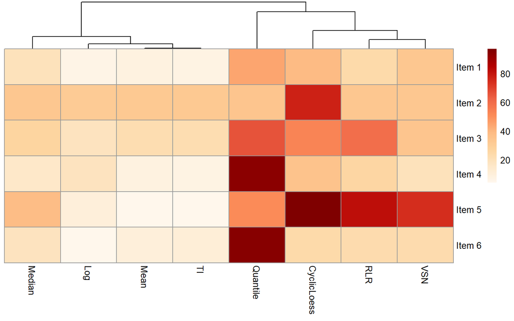

#### Worst normalizations

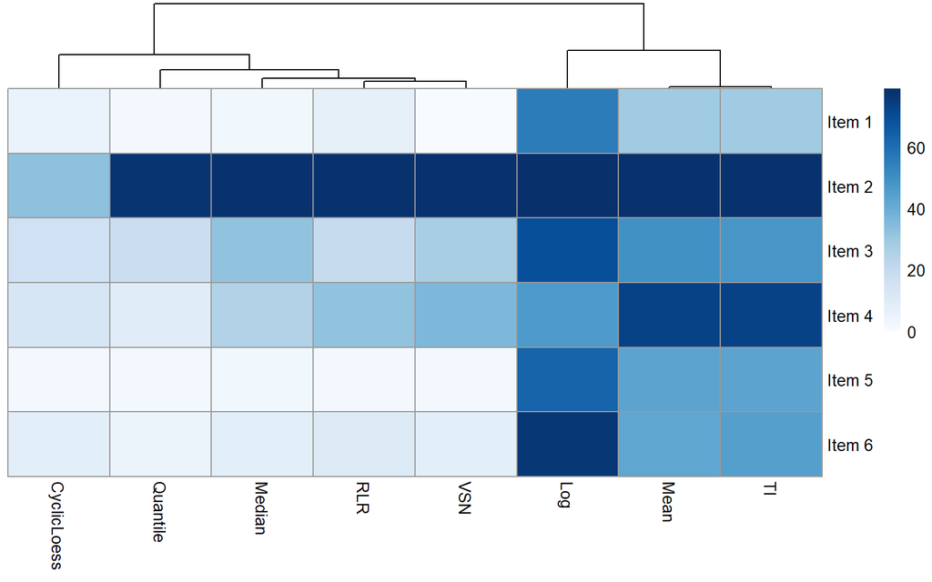

### Global

#### Best (unique)

| Variable | Categorías | Frecuencia absoluta (N) | Frecuencia relativa (%) | Datos faltantes |
| --- | --- | --- | --- | --- |
| Normalization |  | 100 | 1 | 0 (0%) |
|  | CyclicLoess | 12 | 0.12 |  |
|  | Log | 16 | 0.16 |  |
|  | Median | 24 | 0.24 |  |
|  | Quantile | 43 | 0.43 |  |
|  | RLR | 1 | 0.01 |  |
|  | TI | 1 | 0.01 |  |
|  | VSN | 3 | 0.03 |  |

#### Bests

| Variable | Categorías | Frecuencia absoluta (N) | Frecuencia relativa (%) | Datos faltantes |
| --- | --- | --- | --- | --- |
| Normalizations |  | 195 | 1 | 0 (0%) |
|  | CyclicLoess | 40 | 0.205128205128205 |  |
|  | Log | 22 | 0.112820512820513 |  |
|  | Mean | 1 | 0.00512820512820513 |  |
|  | Median | 29 | 0.148717948717949 |  |
|  | Quantile | 75 | 0.384615384615385 |  |
|  | RLR | 15 | 0.0769230769230769 |  |
|  | TI | 2 | 0.0102564102564103 |  |
|  | VSN | 11 | 0.0564102564102564 |  |

#### Worst

| Variable | Categorías | Frecuencia absoluta (N) | Frecuencia relativa (%) | Datos faltantes |
| --- | --- | --- | --- | --- |
| Normalizations |  | 115 | 1 | 0 (0%) |
|  | CyclicLoess | 2 | 0.0173913043478261 |  |
|  | Log | 46 | 0.4 |  |
|  | Mean | 27 | 0.234782608695652 |  |
|  | Median | 4 | 0.0347826086956522 |  |
|  | Quantile | 2 | 0.0173913043478261 |  |
|  | RLR | 7 | 0.0608695652173913 |  |
|  | TI | 27 | 0.234782608695652 |  |

Julia García Currás

Biostatech. Advice, Training & Innovation in Biostatistics S.L. | CITIC. Universidade da Coruña (UDC)